# Tooth Growth Analysis

Ryan Barley

Saturday, December 20, 2014

1. Load the ToothGrowth data and perform some basic exploratory data analyses
2. Provide a basic summary of the data.
3. Use confidence intervals and/or hypothesis tests to compare tooth growth by supp and dose. (Only use the techniques from class, even if there’s other approaches worth considering)
4. State your conclusions and the assumptions needed for your conclusions.

## Load and install required libraries

```r
if (!(require(ggplot2, quietly=T))) {
  install.packages('ggplot2')
}
library(ggplot2)

## Load in Tooth Growth data
data(ToothGrowth)
```

```r
## Get some background information on the dataset
?ToothGrowth
```

```
## starting httpd help server ... done
```

“The response is the length of odontoblasts (teeth) in each of 10 guinea pigs at each of three dose levels of Vitamin C (0.5, 1, and 2 mg) with each of two delivery methods (orange juice or ascorbic acid).”

## Perform some basic exploratory analysis

```r
str(ToothGrowth)
```

```
## 'data.frame':    60 obs. of  3 variables:
##  $ len : num  4.2 11.5 7.3 5.8 6.4 10 11.2 11.2 5.2 7 ...
##  $ supp: Factor w/ 2 levels "OJ","VC": 2 2 2 2 2 2 2 2 2 2 ...
##  $ dose: num  0.5 0.5 0.5 0.5 0.5 0.5 0.5 0.5 0.5 0.5 ...
```

```r
head(ToothGrowth)
```

```
##    len supp dose
## 1  4.2   VC  0.5
## 2 11.5   VC  0.5
## 3  7.3   VC  0.5
## 4  5.8   VC  0.5
## 5  6.4   VC  0.5
## 6 10.0   VC  0.5
```

```r
tail(ToothGrowth)
```

```
##     len supp dose
## 55 24.8   OJ    2
## 56 30.9   OJ    2
## 57 26.4   OJ    2
## 58 27.3   OJ    2
## 59 29.4   OJ    2
## 60 23.0   OJ    2
```

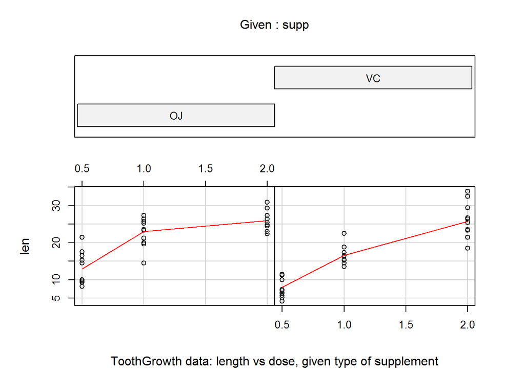

```r
## Look at the graph in help
coplot(len ~ dose | supp, data = ToothGrowth, panel = panel.smooth,
       xlab = "ToothGrowth data: length vs dose, given type of supplement")
```

From this plot, it seems clear that we should treat dosage as a factor, as it is the variable being changed in the experiment. We will convert it to a factor for future analysis.

```r
## Convert dosage variable to factor
ToothGrowth$dose <- as.factor(ToothGrowth$dose)
```

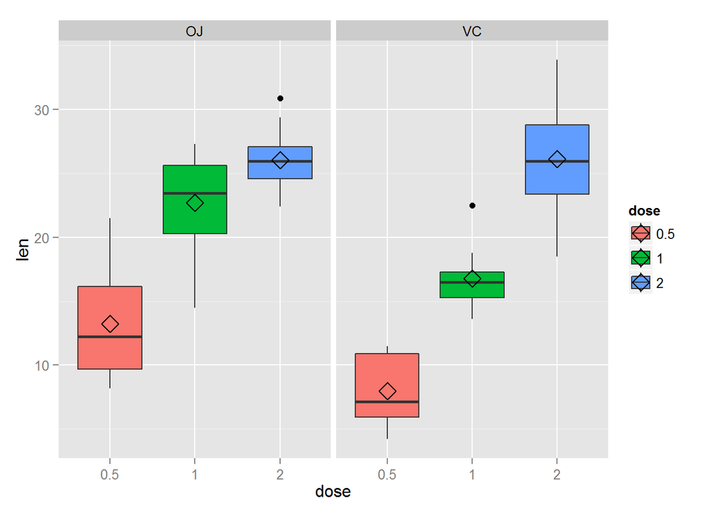

```r
## Make new boxplot
g <- ggplot(ToothGrowth, aes(x = dose, y = len, fill=dose))
g <- g + geom_boxplot(notch=F) + facet_grid(. ~ supp) +
  stat_summary(fun.y = mean, geom = "point", shape = 5, size = 4)
g
```

At first glance, it seems as though both orange juice and ascorbic acid have the same effect on tooth length at sufficiently high doses. However, it seems like orange juice has a greater effect on tooth growth at a basline 0.5mg dose

## Provide a basic summary of the data.

```r
summary(ToothGrowth)
```

```
##       len        supp     dose
##  Min.   : 4.20   OJ:30   0.5:20
##  1st Qu.:13.07   VC:30   1  :20
##  Median :19.25           2  :20
##  Mean   :18.81
##  3rd Qu.:25.27
##  Max.   :33.90
```

From the summary, we can see that the minimum tooth growth was 4.2 (though the documentation contains no units for this measurement). This matches up to the minimum value of a 0.5mg dose of ascorbic acid. However, the maximum value also belongs to the ascorbic acid trial.